# BIOS_HW#1

Jared Garfinkel

9/13/2019

# Biostatistical Methods I

## Problem 1

### Section a

This is a solution for Problem 1, section a.

There is a top row of text that can be ignored for the purposes of creating a dataframe

Change the labels.

Clean the output.

Categorize the variables.

This is a first table.

This is a solution.

```r
summary(solution1a, title = "Demographics and Co-Morbidities", labelTranslations = my_labels,text = TRUE)
```

```
##
## Table: Demographics and Co-Morbidities
##
## |                    |   Intervention (N=36)   |     Control (N=36)      |
## |:-------------------|:-----------------------:|:-----------------------:|
## |Age (yrs)           |                         |                         |
## |-  Mean (SD)        |     51.500 (10.809)     |     53.583 (9.581)      |
## |-  Median (Q1, Q3)  | 51.000 (44.750, 60.250) | 55.500 (47.500, 59.250) |
## |Gender              |                         |                         |
## |-  Male             |       16 (44.4%)        |       16 (44.4%)        |
## |-  Female           |       20 (55.6%)        |       20 (55.6%)        |
## |Race                |                         |                         |
## |-  African American |       22 (61.1%)        |       31 (86.1%)        |
## |-  Hispanic         |       14 (38.9%)        |        5 (13.9%)        |
## |Hypertensive        |                         |                         |
## |-  Yes              |       16 (44.4%)        |       14 (38.9%)        |
## |-  No               |       20 (55.6%)        |       22 (61.1%)        |
## |Type 2 Diabetes     |                         |                         |
## |-  Yes              |       17 (47.2%)        |       23 (63.9%)        |
## |-  No               |       19 (52.8%)        |       13 (36.1%)        |
## |Depression          |                         |                         |
## |-  Yes              |       23 (63.9%)        |       26 (72.2%)        |
## |-  No               |       13 (36.1%)        |       10 (27.8%)        |
## |Smoker              |                         |                         |
## |-  Yes              |       31 (86.1%)        |       31 (86.1%)        |
## |-  No               |        5 (13.9%)        |        5 (13.9%)        |
```

## Section 1bi

This is a solution for Section 1b.

Start with the labels.

Clean the output.

Use only the variables we are looking at.

Make a table.

Create a dataframe that splits data by factor.

Changes in Metabolic Paramaters

| —— | Intervention |  | Control |  |
| --- | --- | --- | --- | --- |
| —— | Baseline | 6-months | Baseline | 6-months |
| Systolic Blood Pressure (mm Hg) | 133.64 +/- 15.11 | 125.06 +/- 15.44 | 133.47 +/- 15.94 | 130.14 +/- 14.35 |
| —— | 134 (121.5, 144) | 124 (116.75, 135) | 131 (122.5, 143.5) | 127.5 (120, 140) |
| $\Delta$ | ——– | -8.58 +/- 17.17 | ——– | -3.33 +/- 14.81 |
| Diastolic Blood Pressure (mm Hg) | 75.44 +/- 9.1 | 74.58 +/- 12.37 | 77.14 +/- 9.66 | 75.69 +/- 7.54 |
| —— | 74.5 (69, 81) | 74 (65, 80.5) | 76 (68.75, 85) | 76.5 (69, 82) |
| $\Delta$ | ——– | -0.86 +/- 8.3 | ——– | -1.44 +/- 10.11 |
| Body Mass Index | 31.97 +/- 6.58 | 31.21 +/- 6.13 | 34.23 +/- 6.16 | 34.51 +/- 5.97 |
| —— | 29.25 (27.375, 34.1) | 29.15 (26.8, 32.875) | 33.4 (29.6, 37.575) | 33.05 (30.425, 37.55) |
| $\Delta$ | ——– | -0.76 +/- 1.44 | ——– | 0.28 +/- 0.97 |
| HDL Cholesterol (mg/dL) | 50.17 +/- 11.85 | 50.17 +/- 13.07 | 48.33 +/- 13.7 | 45.19 +/- 10.78 |
| —— | 47.5 (40, 60) | 48.5 (43, 60.25) | 43.5 (39, 54.25) | 43.5 (38, 52) |
| $\Delta$ | ——– | 0 +/- 8.09 | ——– | -3.14 +/- 6.91 |
| LDL Cholesterol (mg/dL) | 102.94 +/- 33.84 | 100.5 +/- 30.39 | 99.83 +/- 29.06 | 93.61 +/- 27.47 |
| —— | 109 (75.25, 124.5) | 95 (76.5, 120.5) | 104 (88.25, 112.25) | 96.5 (77.5, 110.25) |
| $\Delta$ | ——– | -2.44 +/- 21.27 | ——– | -6.22 +/- 23.12 |
| Blood Glucose Level (mmol/L) | 116.64 +/- 74.91 | 107.14 +/- 38.65 | 128.97 +/- 73.86 | 126.61 +/- 63.96 |
| —— | 94 (83.75, 116.5) | 95.5 (85.25, 129) | 98 (81.75, 139) | 106.5 (85, 145.75) |
| $\Delta$ | ——– | -9.5 +/- 57.36 | ——– | -2.36 +/- 51.22 |

# Problem 1bii

Two boxplots of intervention groups.

This is a boxplot of BMI with the intervention group on the left and the control on the right. The control started off higher, maybe since it is a self selected participation in exercise.

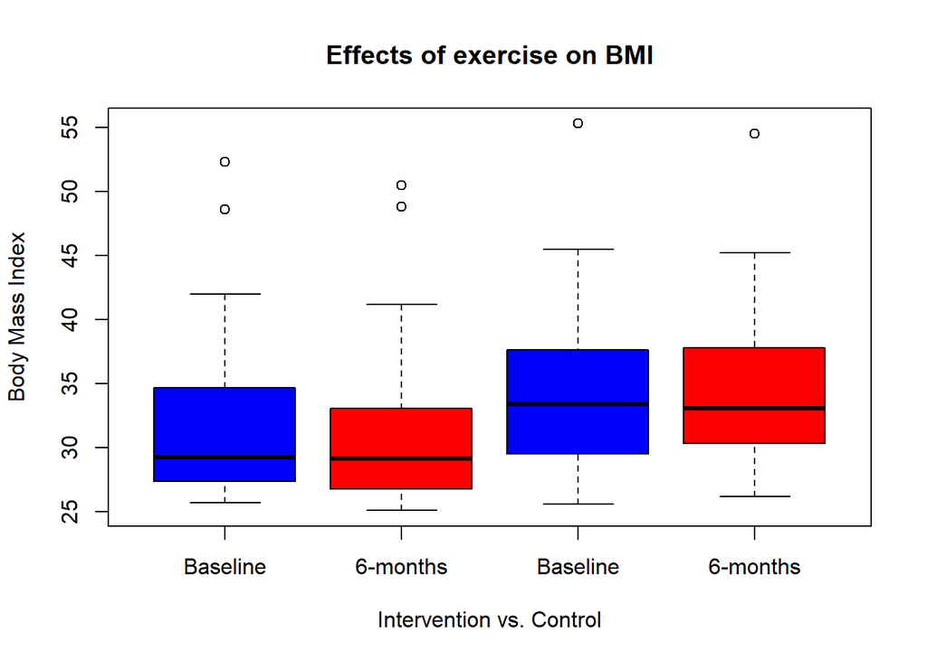

```r
boxplot(BMI_good,
        names = BMI_labels,
        xlab = "Intervention vs. Control",
        ylab = "Body Mass Index",
        col = c("blue","red"),
        main = "Effects of exercise on BMI")
```

This is a boxplot of LDL with the intervention group on the left and the control on the right.

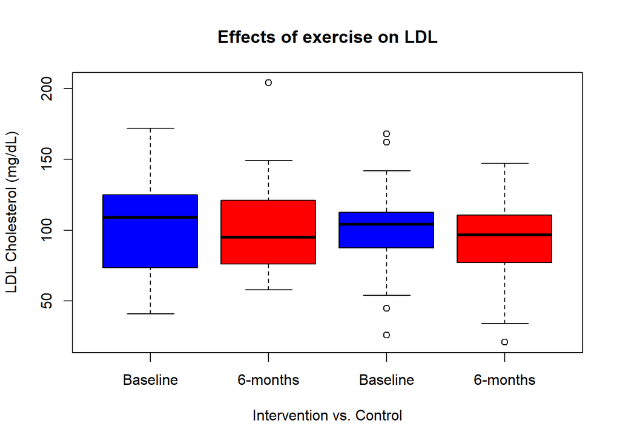

```r
boxplot(LDL_good,
        names = LDL_labels,
        xlab = "Intervention vs. Control",
        ylab = "LDL Cholesterol (mg/dL)",
        col = c("blue","red"),
        main = "Effects of exercise on LDL")
```

## Section 1biii

These findings indicate that among the intervention and control

groups there were no changes in BMI and LDL. This might be because

of the matching technique used, where participants and non-participants

were matched by gender. In addition, the intervention group was self selected,

so they may have already been inclined to exercise or live a healthier lifestyle.

indicators.

# Problem 2

The probability that a triple test of a fetus with down syndrome is positive

is P(+|DS) = 0.60.

The probability that a triple test of a fetus that does not have down syndrome is positive

is P(+|NDS) = 0.05.

The probability of a fetus being born with Down Syndrom is P(DS) = 0.001

What is the probability that a fetus with a positive test result actually has Down Syndrome? P(DS|+) = ?

P(DS|+) =
$$P(+|DS)*P(DS) / (P(+|DS)*P(DS)+P(+|NDS)*P(NDS))$$

=
$$0.60*0.001 / (0.60*0.001+0.05*(1-0.001))$$

= 0.01

This is called a positive predictive value. Because the positive predictive value

of this test is less than two percent, it is very unlikely to be accurate.

This might mean doing the test two, three, or more times to achieve a reasonable

level of certainty regarding the presence of the condition.

# Problem 3

The media reported widely on a story about an article titled, “Habitual tea drinking modulates brain efficiency: evidence from brain connectivity evaluation” published in the journal, “Aging” based in Albany, NY. The study used neuroimaging from subjects split into two groups, “tea drinkers” and “non-tea drinkers” to analyze differences in brain structure. Reporting on the findings had some similarities. For instance, all the reporting in this analysis promoted the benefits of drinking tea for healthy aging and brain structure. Some of the media included descriptions of the methods, like the number of participants and the thing being studied. There were also references to brain structure in all the articles, which was the main topic of the paper. One reporter claimed the study took place over three years.

I think the reporting was fairly measured across the board. This is reasonable considering it is an exploratory analysis. One thing that I found interesting is that the authors used leftward assymetry to measure the amount of aging on a brain. One of the main findings of the paper was that there was more leftward assymetry in the non-tea drinking group. The study was meant to add to the literature suggesting a correlation between drinking tea and healthier aging. I think the authors accomplished this even though the study size was small (n=36) and the results were mixed. While functional brain networks were found to be more efficient among “tea drinkers”, structural brain networks were not.

While this is an early look at the brain structure of tea drinkers compared to non-tea drinkers, it follows a large amount of literature suggesting the health benefits of drinking tea. In fact, the authors of this study conducted a longitudinal study of tea drinkers in 2017 that had encouraging results. There have also been press releases from Harvard University promoting the health benefits of tea on several health factors. In the future, studies like this may determine the mechanisms by which tea can bolster health. Until then, I think it is safe to continue to drink tea, which may even impart a benefit.

### Sources:

#### 1. https://www.mindbodygreen.com/articles/new-study-shows-regular-tea-drinkers-have-better-organized-brain-regions?fbclid=IwAR34Q8CrrYFvod61zpOolK803psG88POnQdeDGr8l_jY9CQN8CE-97_DVWQ

#### 2. https://www.sciencedaily.com/releases/2019/09/190912100945.htm

#### 3. https://www.businessinsider.sg/drinking-tea-could-save-your-brain-from-old-age-decline-nus-led-study-finds/

#### 4. https://neurosciencenews.com/tea-drinking-brain-health-14889/

#### 5. https://www.independent.co.uk/life-style/health-and-families/tea-brain-health-boost-ageing-green-black-oolong-a9107546.html

#### 6. https://www.aging-us.com/article/102023/text